# Section 6.5: Matched Pairs Inference for Means with R

This help sheet shows how to use built-in R procedures to carry out examples of matched pairs inference for means in Section 6.5. The primary R procedure for $t$ inference is `t.test()`. Note that the matched pairs design may typically be viewed simply as inference about a single mean, once differences in the matched pairs have been computed.

**Example 6.29 Matched Pairs Hypothesis Test**

```r
head(Wetsuits)
```

```
  Wetsuit NoWetsuit Gender       Type
1    1.57      1.49      F    swimmer
2    1.47      1.37      F triathlete
3    1.42      1.35      F    swimmer
4    1.35      1.27      F triathlete
5    1.22      1.12      M triathlete
6    1.75      1.64      M    swimmer
```

I recommend computing and saving the differences in the original data set and then plotting the data before proceeding.

The code below uses the `mutate()` command to compute and add a column of differences (Wetsuit-NoWet) to the original data set:

```r
Wetsuits <- mutate(Wetsuits, diff = Wetsuit - NoWetsuit)
```

Now plot a dotplot of the differences as shown in the text:

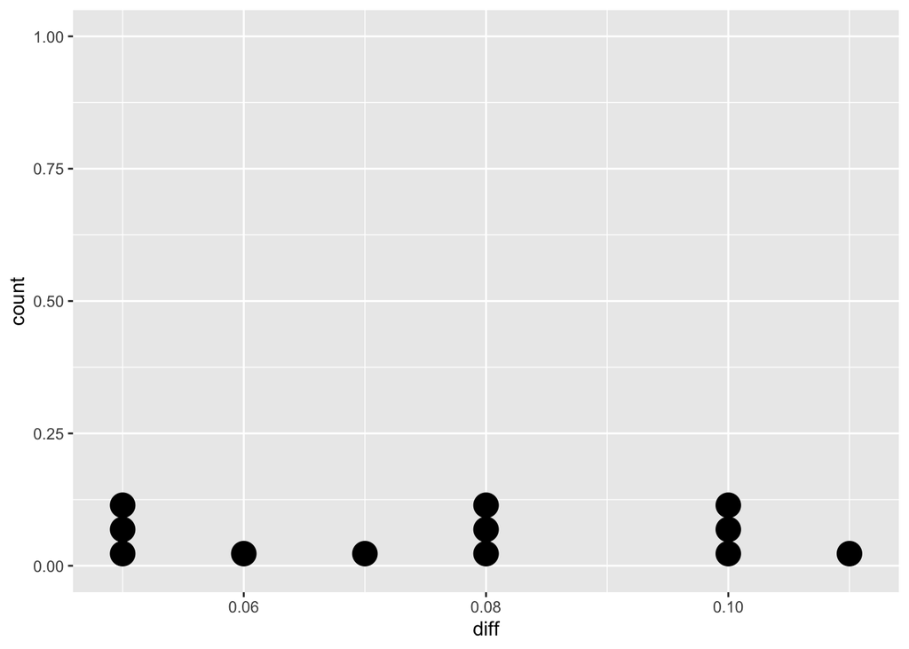

```r
gf_dotplot(~diff, data = Wetsuits)
```

Although it is difficult to see a bell-shape for samples this small, the differences look relatively symmetric and have no clear outliers, so we don’t detect any serious problems with normality and can proceed with the t-distribution.

Below is the R code for a one-sided hypothesis test.

```r
t.test(~diff, data = Wetsuits, alt = "greater")
```

```
    One Sample t-test

data:  diff
t = 12.32, df = 11, p-value = 4.44e-08
alternative hypothesis: true mean is greater than 0
95 percent confidence interval:
 0.0662011       Inf
sample estimates:
mean of x
   0.0775
```

The very large t-statistic and small p-value provide very convincing evidence that swimmers are faster on average when wearing wetsuits. Because this was a randomized experiment, we can conclude that wetsuits cause swimmers to swim faster.

**Example 6.30 Matched Pairs Confidence Interval**

Below is the R code for a 95% confidence interval. Note that 95% is the default value and need not be specified explicitly.

```r
t.test(~diff, data = Wetsuits, conf.level = .95)
```

```
    One Sample t-test

data:  diff
t = 12.32, df = 11, p-value = 8.89e-08
alternative hypothesis: true mean is not equal to 0
95 percent confidence interval:
 0.0636524 0.0913476
sample estimates:
mean of x
   0.0775
```

We are 95% confident that for competitive swimmers and triathletes, wetsuits increase maximum swimming velocity by an average of between 0.064 and 0.091 meters per second.

Note: Occasionally it is useful to plot the paired values to verify the paired, correlated nature of the data. It is this correlation that provides the gain in sensitivity of paired t analysis compared to the independent two samples t method.

```r
cor(Wetsuit ~ NoWetsuit, data = Wetsuits)
```

```
[1] 0.988243
```

A plot of the paired data verifies the high correlation meaning that the fastest swimmers are fastest regardless of whether they are wearing a wetsuit or not.

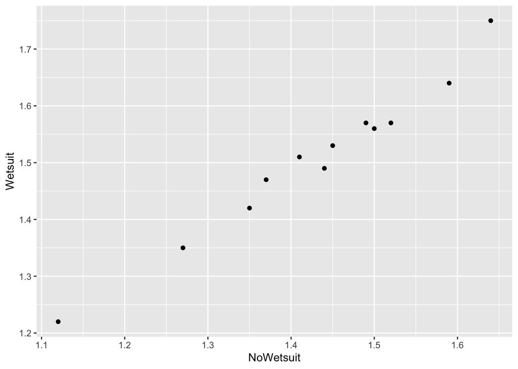

```r
gf_point(Wetsuit ~ NoWetsuit, data = Wetsuits)
```